# Figure S3a: Identifying ATAC regions with differential H3K27Ac

**Project:** Enhancer identification

**Author:** Jeff Johnston

**Generated:** Wed Aug 24 2016, 07:48 PM

## Overview

Outline:

- Call ATAC peaks in wild-type whole-embryo 2-4h sample
- Divide into groups: near TSS, inside gene, intergenic
- Measure H3K27Ac signal in 1kb window around summit for Toll10b and gd7
- Identify peaks with differential H3K27Ac (DESeq2)

## Peak calling

MACS2 was run on the combined two replicates of ATAC-seq in 2-4h embryos, yielding the following number of peaks:

| Sample | Peaks |
| --- | --- |
| ATAC 2-4h | 29,510 |

## Classify peaks by proximity to nearest gene

Each peak will be assigned to one of the following categories:

- TSS (within 1kb of a TSS)
- Inside gene
- Intergenic

| classification | Count |
| --- | --- |
| Inside_Gene | 12,549 |
| Intergenic | 3,944 |
| TSS | 13,017 |

## DESeq

Using the H3K27Ac read counts for two replicates each of Toll10b and gd7 samples, we call differentially-bound peaks using DESeq2. This results in the following numbers of peaks (adjusted p-value < 0.01):

| classification | No_Change | Up_gd7 | Up_Toll10b |
| --- | --- | --- | --- |
| Inside_Gene | 12,138 | 175 | 236 |
| Intergenic | 3,791 | 61 | 92 |
| TSS | 12,691 | 125 | 201 |

Below is a plot of the H3K27Ac signal at each ATAC region for the two tissues, highlighting those called significantly different by DESeq:

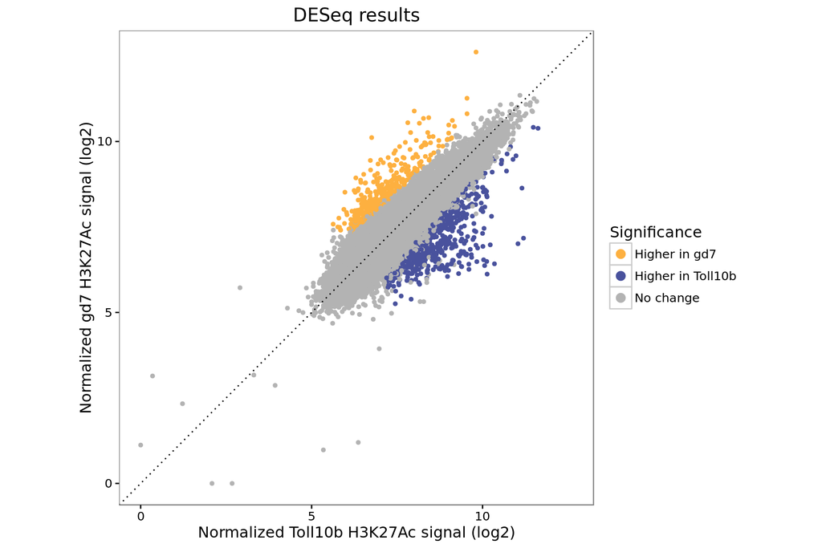

Of the 59 known enhancers, 29 overlap an ATAC differential H3K27Ac region.

Including only non-TSS regions, we detect differential H3K27Ac at 16 known enhancers.

## Number of detected enhancers per gene

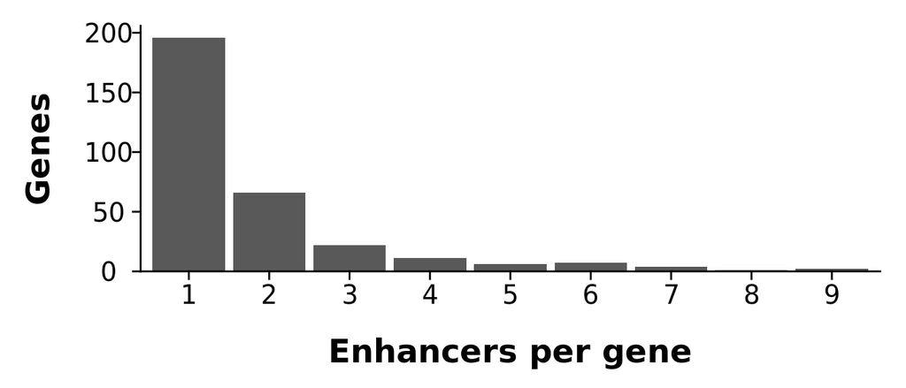

| Var1 | Freq |
| --- | --- |
| 1 | 196 |
| 2 | 66 |
| 3 | 22 |
| 4 | 11 |
| 5 | 6 |
| 6 | 7 |
| 7 | 4 |
| 8 | 1 |
| 9 | 2 |

## Session information

For reproducibility, this analysis was performed with the following R/Bioconductor session:

```
R version 3.2.0 (2015-04-16)
Platform: x86_64-pc-linux-gnu (64-bit)
Running under: Ubuntu 15.04

locale:
 [1] LC_CTYPE=en_US.UTF-8       LC_NUMERIC=C
 [3] LC_TIME=en_US.UTF-8        LC_COLLATE=en_US.UTF-8
 [5] LC_MONETARY=en_US.UTF-8    LC_MESSAGES=en_US.UTF-8
 [7] LC_PAPER=en_US.UTF-8       LC_NAME=C
 [9] LC_ADDRESS=C               LC_TELEPHONE=C
[11] LC_MEASUREMENT=en_US.UTF-8 LC_IDENTIFICATION=C

attached base packages:
 [1] grid      stats4    parallel  stats     graphics  grDevices utils
 [8] datasets  methods   base

other attached packages:
 [1] tidyr_0.6.0                           lattice_0.20-33
 [3] reshape2_1.4.1                        digest_0.6.10
 [5] yaml_2.1.13                           pander_0.6.0
 [7] magrittr_1.5                          readr_1.0.0
 [9] DESeq2_1.10.1                         RcppArmadillo_0.7.200.2.0
[11] Rcpp_0.12.6                           SummarizedExperiment_1.0.2
[13] Biobase_2.30.0                        BSgenome.Dmelanogaster.UCSC.dm3_1.4.0
[15] BSgenome_1.38.0                       rtracklayer_1.30.4
[17] Biostrings_2.38.4                     XVector_0.10.0
[19] dplyr_0.5.0                           stringr_1.0.0
[21] ggplot2_2.1.0                         GenomicRanges_1.22.4
[23] GenomeInfoDb_1.6.3                    IRanges_2.4.8
[25] S4Vectors_0.8.11                      BiocGenerics_0.16.1
[27] xtable_1.8-2                          setwidth_1.0-4

loaded via a namespace (and not attached):
 [1] splines_3.2.0              Formula_1.2-1
 [3] assertthat_0.1             latticeExtra_0.6-28
 [5] Rsamtools_1.22.0           RSQLite_1.0.0
 [7] chron_2.3-47               RColorBrewer_1.1-2
 [9] colorspace_1.2-6           htmltools_0.3.5
[11] Matrix_1.2-6               plyr_1.8.4
[13] XML_3.98-1.4               genefilter_1.52.1
[15] zlibbioc_1.16.0            scales_0.4.0
[17] BiocParallel_1.4.3         tibble_1.1
[19] annotate_1.48.0            lazyeval_0.2.0
[21] nnet_7.3-12                survival_2.39-5
[23] evaluate_0.9               foreign_0.8-66
[25] tools_3.2.0                data.table_1.9.6
[27] formatR_1.4                munsell_0.4.3
[29] locfit_1.5-9.1             cluster_2.0.4
[31] AnnotationDbi_1.32.3       lambda.r_1.1.9
[33] RStudioConsoleRender_0.1.0 futile.logger_1.4.3
[35] RCurl_1.95-4.8             rstudioapi_0.6
[37] labeling_0.3               bitops_1.0-6
[39] rmarkdown_1.0              gtable_0.2.0
[41] DBI_0.5                    R6_2.1.2
[43] GenomicAlignments_1.6.3    gridExtra_2.2.1
[45] knitr_1.14                 Hmisc_3.17-4
[47] futile.options_1.0.0       stringi_1.1.1
[49] geneplotter_1.48.0         rpart_4.1-10
[51] acepack_1.3-3.3
```